# StatData1: forel220919

Anders Tolver

# Ensidet variansanalyse

Her vises hvordan man kan estimere parametrene (dvs. finde *punktestimater*) i en ensidet variansanalysemodel (ANOVA). Vi regner på datasættet `antibio` der bl.a. blev diskuteret på slides og R program til forelæsningen d. 7/9-2022 (-se også s. 53 og 114 i lærebogen).

Det er vigtigt at hæfte sig ved at

- en ensidet ANOVA kan skrives på flere måder, nemlig med/uden referencegruppe, og man kan skifte referencegruppen
- R-afsnittet i kapitel 5 også gennemgår dette eksempel

## Indlæsning og visualisering af data

```r
library(isdals)
data(antibio)
head(antibio)
```

```
##       type  org
## 1 Ivermect 3.03
## 2 Ivermect 2.81
## 3 Ivermect 3.06
## 4 Ivermect 3.11
## 5 Ivermect 2.94
## 6 Ivermect 3.06
```

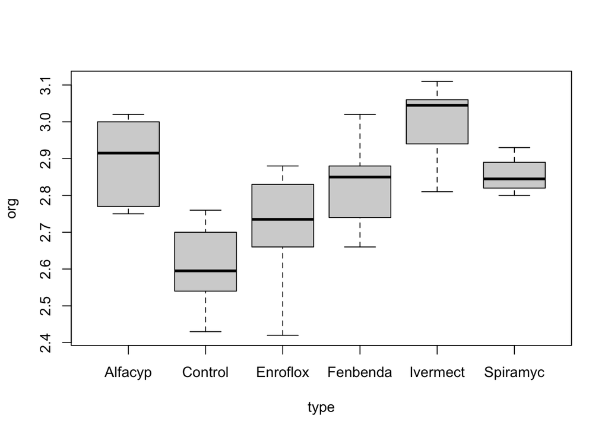

```r
boxplot(org ~ type, data = antibio)
```

Ved ensidet ANOVA interesserer man sig primært for den gennemsnitlige (dvs. forventede) værdi af en måling fra hver gruppe.

Vi minder om følgende *smarte* metode til at foretage udregninger af stikprøvestørrelser for en kvantitativ, kontinuert måling, når man samtidig ønsker at foretage udregninger opdelt på forskellige grupper givet ved en kategorisk variabel.

Udregning af gennemsnit og spredning for hver gruppe

```r
summarise(group_by(antibio, type), mean_org = mean(org), sd_org = sd(org))
```

```
## # A tibble: 6 × 3
##   type     mean_org sd_org
##   <fct>       <dbl>  <dbl>
## 1 Alfacyp      2.90 0.117
## 2 Control      2.60 0.119
## 3 Enroflox     2.71 0.162
## 4 Fenbenda     2.83 0.124
## 5 Ivermect     3.00 0.109
## 6 Spiramyc     2.86 0.0545
```

## Ensidet variansanalysemodel

Ved en ensidet variansanalysemodel antager vi at målingerne i hver gruppe er normalfordelte med samme varians, men at middelværdien kan være forskellig i de forskellige grupper. Alle målinger antages at være uafhængige.

Vi ønsker primært at udtale os om (populations-)middelværdierne i de forskellige grupper på baggrund af de givne data.

Vi fokuserer her på, at der er forskellige måder man kan vælge at beskrive (eller parametrisere) middelværdierne i de seks grupper.

### Parametrisering ved de seks gruppegennemsnit

- Følgende R kode estimerer direkte de seks gruppegennemsnit.

```r
### Model, parametrisering med de seks gennemsnit
model1 <- lm(org ~ type - 1, data=antibio)
summary(model1)
```

```
##
## Call:
## lm(formula = org ~ type - 1, data = antibio)
##
## Residuals:
##      Min       1Q   Median       3Q      Max
## -0.29000 -0.06000  0.01833  0.07250  0.18667
##
## Coefficients:
##              Estimate Std. Error t value Pr(>|t|)
## typeAlfacyp   2.89500    0.04970   58.25   <2e-16 ***
## typeControl   2.60333    0.04970   52.38   <2e-16 ***
## typeEnroflox  2.71000    0.04970   54.53   <2e-16 ***
## typeFenbenda  2.83333    0.04970   57.01   <2e-16 ***
## typeIvermect  3.00167    0.04970   60.39   <2e-16 ***
## typeSpiramyc  2.85500    0.06087   46.90   <2e-16 ***
## ---
## Signif. codes:  0 '***' 0.001 '**' 0.01 '*' 0.05 '.' 0.1 ' ' 1
##
## Residual standard error: 0.1217 on 28 degrees of freedom
## Multiple R-squared:  0.9985, Adjusted R-squared:  0.9981
## F-statistic:  3034 on 6 and 28 DF,  p-value: < 2.2e-16
```

```r
confint(model1)
```

```
##                 2.5 %   97.5 %
## typeAlfacyp  2.793191 2.996809
## typeControl  2.501524 2.705142
## typeEnroflox 2.608191 2.811809
## typeFenbenda 2.731524 2.935142
## typeIvermect 2.899858 3.103476
## typeSpiramyc 2.730310 2.979690
```

### Model med Alfacyp som referencegruppe

- Hvis man ikke skriver `-1`, så bruger R en af grupperne som referencegruppe, nemlig den der kommer først i alfabetet.
- Referencegruppen nævnes ikke eksplicit i outputtet, men står som `Intercept`. Alle andre estimater er givet som forskelle til referencegruppen.

```r
### Model med Alfacyp som referencegruppe
model2 <- lm(org ~ type, data=antibio)
summary(model2)
```

```
##
## Call:
## lm(formula = org ~ type, data = antibio)
##
## Residuals:
##      Min       1Q   Median       3Q      Max
## -0.29000 -0.06000  0.01833  0.07250  0.18667
##
## Coefficients:
##              Estimate Std. Error t value Pr(>|t|)
## (Intercept)   2.89500    0.04970  58.248  < 2e-16 ***
## typeControl  -0.29167    0.07029  -4.150 0.000281 ***
## typeEnroflox -0.18500    0.07029  -2.632 0.013653 *
## typeFenbenda -0.06167    0.07029  -0.877 0.387770
## typeIvermect  0.10667    0.07029   1.518 0.140338
## typeSpiramyc -0.04000    0.07858  -0.509 0.614738
## ---
## Signif. codes:  0 '***' 0.001 '**' 0.01 '*' 0.05 '.' 0.1 ' ' 1
##
## Residual standard error: 0.1217 on 28 degrees of freedom
## Multiple R-squared:  0.5874, Adjusted R-squared:  0.5137
## F-statistic: 7.973 on 5 and 28 DF,  p-value: 8.953e-05
```

```r
confint(model2)
```

```
##                    2.5 %      97.5 %
## (Intercept)   2.79319111  2.99680889
## typeControl  -0.43564618 -0.14768716
## typeEnroflox -0.32897951 -0.04102049
## typeFenbenda -0.20564618  0.08231284
## typeIvermect -0.03731284  0.25064618
## typeSpiramyc -0.20097398  0.12097398
```

### Skift af referencegruppe

- Det er mere naturligt at bruge kontrolgruppen som reference. Dette kan opnås ved at bruge relevel.

```r
### Model med Control som referencegruppe
antibio$myType <- relevel(antibio$type, ref="Control")
# antibio$type
# antibio$myType
model3 <- lm(org ~ myType, data=antibio)
summary(model3)
```

```
##
## Call:
## lm(formula = org ~ myType, data = antibio)
##
## Residuals:
##      Min       1Q   Median       3Q      Max
## -0.29000 -0.06000  0.01833  0.07250  0.18667
##
## Coefficients:
##                Estimate Std. Error t value Pr(>|t|)
## (Intercept)     2.60333    0.04970  52.379  < 2e-16 ***
## myTypeAlfacyp   0.29167    0.07029   4.150 0.000281 ***
## myTypeEnroflox  0.10667    0.07029   1.518 0.140338
## myTypeFenbenda  0.23000    0.07029   3.272 0.002834 **
## myTypeIvermect  0.39833    0.07029   5.667  4.5e-06 ***
## myTypeSpiramyc  0.25167    0.07858   3.202 0.003384 **
## ---
## Signif. codes:  0 '***' 0.001 '**' 0.01 '*' 0.05 '.' 0.1 ' ' 1
##
## Residual standard error: 0.1217 on 28 degrees of freedom
## Multiple R-squared:  0.5874, Adjusted R-squared:  0.5137
## F-statistic: 7.973 on 5 and 28 DF,  p-value: 8.953e-05
```

```r
confint(model3)
```

```
##                      2.5 %    97.5 %
## (Intercept)     2.50152445 2.7051422
## myTypeAlfacyp   0.14768716 0.4356462
## myTypeEnroflox -0.03731284 0.2506462
## myTypeFenbenda  0.08602049 0.3739795
## myTypeIvermect  0.25435382 0.5423128
## myTypeSpiramyc  0.09069268 0.4126407
```

Hvis man helt sikker på, at man altid vil ønske at benytte `Control`-gruppen som reference, så er der ingen grund til at lave en ny variabel `myType` i datasættet. Koden ovenfor kan da blot erstattes med

```r
antibio$type <- relevel(antibio$type, ref="Control")
model3 <- lm(org ~ type, data=antibio)
```

### Bemærkninger og resultater til de 3 viste metoder

# Lineær regression

Vi vender tilbage til datasættet med sammenhørende målinger af kropsvægt og hjertevægt for katte.

```r
library(MASS)
data(cats)
head(cats)
```

```
##   Sex Bwt Hwt
## 1   F 2.0 7.0
## 2   F 2.0 7.4
## 3   F 2.0 9.5
## 4   F 2.1 7.2
## 5   F 2.1 7.3
## 6   F 2.1 7.6
```

## Lineær regressionsmodel, scatterplot af data og regressionslinje

Ved en lineær regressionanalyse ønsker vi at bestemme en ret linje med ligningen

> y = a + b * x

som passer bedst muligt med de observerede datapunkter. Her tænker vi på

- `y = Hwt` (heart weight) som responsen
- `x = Bwt` (body weight) som den forklarende variabel

Når vi laver lineær regression tænker vi på responsen (y) som trukket fra normalfordeling med middelværdi a + b * x. Hvis vi kender værdien af den forklarende variabel (x) så vil punktet på regressionslinjen (a + b * x) angive den forventede/gennemsnitlige værdi af responsen (y). Variationen omkring linjen vælger vi at beskrive ved (uafhængige) normalfordelte variable med middelværdi 0 og samme spredning.

De (ukendte) parametre a og b der beskriver regressionslinjen estimeres ved mindste kvadraters metode fx. når man benytter `lm()`-funktionen i R som nedenfor.

```r
linreg <- lm(Hwt ~ Bwt, data=cats)
summary(linreg)
```

```
##
## Call:
## lm(formula = Hwt ~ Bwt, data = cats)
##
## Residuals:
##     Min      1Q  Median      3Q     Max
## -3.5694 -0.9634 -0.0921  1.0426  5.1238
##
## Coefficients:
##             Estimate Std. Error t value Pr(>|t|)
## (Intercept)  -0.3567     0.6923  -0.515    0.607
## Bwt           4.0341     0.2503  16.119   <2e-16 ***
## ---
## Signif. codes:  0 '***' 0.001 '**' 0.01 '*' 0.05 '.' 0.1 ' ' 1
##
## Residual standard error: 1.452 on 142 degrees of freedom
## Multiple R-squared:  0.6466, Adjusted R-squared:  0.6441
## F-statistic: 259.8 on 1 and 142 DF,  p-value: < 2.2e-16
```

```r
confint(linreg)
```

```
##                 2.5 %   97.5 %
## (Intercept) -1.725163 1.011838
## Bwt          3.539343 4.528782
```

Vi aflæser umiddelbart følgende af R udskriften ovenfor

- Skæringen a (der beskrive regressionslinjens værdi for x = 0) estimeres til -0.3567 (SE 0.6923). Tallet er i sig selv ret uinteressant, men estimatet er vigtigt for at kunne indtegne den estimerede regressionslinje.
- Hældningen estimeres til 4.034 (SE 0.250). For to katte med en forskel i kropsvægt på 1 kg vil vi altså forvente en forskel i hjertevægt på 4.034 g. 95% konfidensintervallet for hældningen er (3.539, 4.529). Dette er altså de værdier af hældningen der stemmer overens med data.

Figuren angiver et scatterplot for de parrede målinger af (x,y). Den estimerede regressionslinje er indtegnet på figuren.

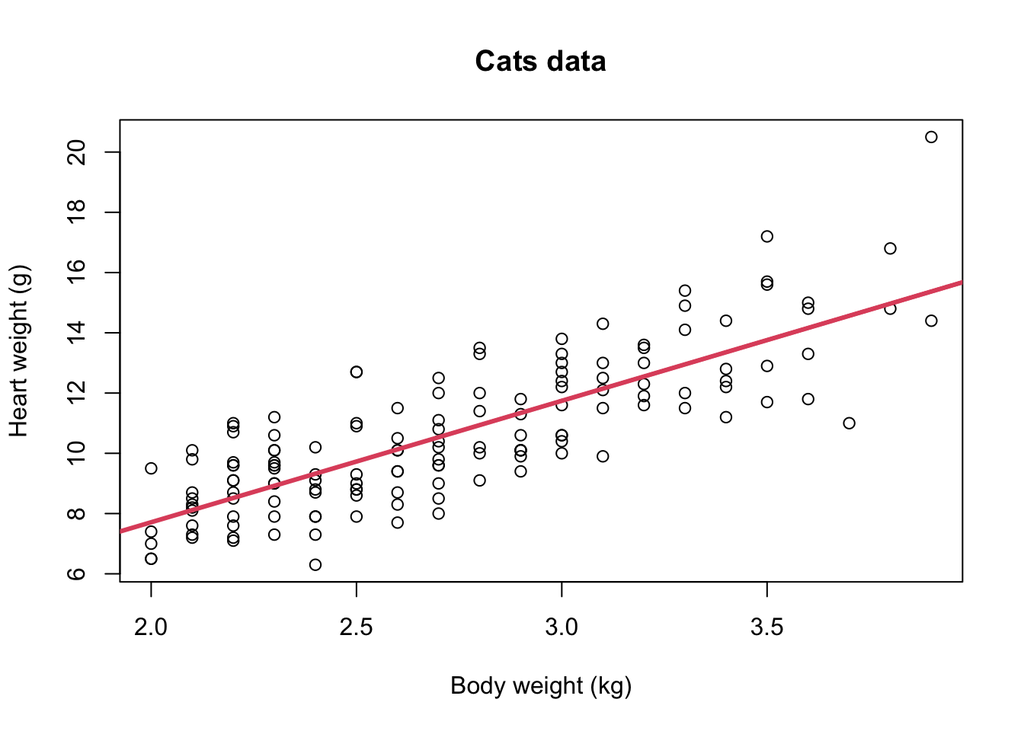

```r
plot(Hwt ~ Bwt, data=cats, pch=1, xlab="Body weight (kg)", ylab="Heart weight (g)", main="Cats data")
abline(linreg, col=2, lwd=3)
```

## Beregning af estimat og konfidensinterval for punkt på linjen

Antag at vi er interesseret i estimat og KI for den forventede hjertevægt for en kat med kropsvægt på 2.5 kg.

For at beregne estimatet kan vi blot indsætte værdien `x = 2.5`sammen med estimaterne for `a` og `b` i ligningen

> y = a + b * x.

Hvis vi ønsker at beregne et konfidensinterval for dette punkt på linjen, så kan vi med fordel trække på `predict()`-funktionen i R.

- Vi laver et nyt datasæt (`newData`) der kun indeholder kropsvægten 2.5.
- Dernæst bruger vi funktionen `predict()` med den estimerede regressionsmodel (her: `linreg`) og det nye datasæt `newData`.

```r
### Nyt datasæt med een obsvation og kun med højdevariabel
newData <- data.frame(Bwt=2.5)
newData
```

```
##   Bwt
## 1 2.5
```

```r
### Kun estimatet
predict(linreg, newData)
```

```
##        1
## 9.728494
```

```r
### Nu estimat og konfidensinterval
predict(linreg, newData, interval="confidence", level = 0.95)
```

```
##        fit      lwr      upr
## 1 9.728494 9.464902 9.992087
```

- Den gennemsnitslige hjertevægt blandt katte på 2.5 kg estimeres til 9.72 g med 95% konfidensinterval (9.46, 9.99). Bemærk at dette interval udtaler sig om gennemsnittet (af hjertevægten) for katte med kropsvægt på 2.5 kg - ikke om værdien for en enkelt kat. Konfidensintervallet skal *ikke* fortolkes sådan, at det vil indeholde ca. 95 % af fremtidige målinger for katte med kropsvægt på 2.5 kg.